# R Notebook

```r
library(plotrix)
```

# Problem 1.169

# A) Solution:

```r
# EAR
mean = 60
# percent of RDA (p-value)
pz = .9772
# RDA
A = 75

# find z-value from p-value
z= round(qnorm(pz, lower.tail = TRUE),2)
print(paste("z score for RDA is", z))
```

```
## [1] "z score for RDA is 2"
```

```r
sd = (A-mean)/z
print(paste("Standard deviation of the requirement distribution is",sd))
```

```
## [1] "Standard deviation of the requirement distribution is 7.5"
```

# B) Solution:

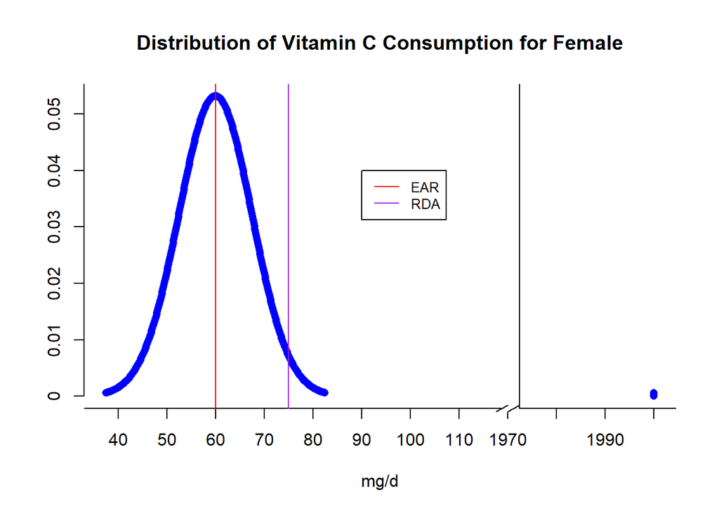

```r
ul = 2000
xmin = mean-sd*3
xmax = mean+sd*3
# Create a sequence of numbers between xmin and 2000 incrementing by 0.1
x <- seq(xmin, ul, by = .1)
xgap <- ifelse(x>xmax,2000, x)
# Choose the mean as 60 and standard deviation as 7.5.
y <- dnorm(x, mean, sd)
par(bty="n") # deleting the box
gap.plot(xgap,y, gap=c(120,1970), gap.axis="x", pch=16,
         col="blue", ylim=range(y),
         xtics=c(seq(30, 120, by = 10),seq(1970, 2010, by = 10)),
         xticlab=c(seq(30, 120, by = 10),seq(1970, 2010, by = 10)), xlab = 'mg/d',
         ylab ='', main="Distribution of Vitamin C Consumption for Female")
abline(v=mean, col="red")    #add EAR line
abline(v=A, col="purple")    # add RDA line
abline(v=seq(120,1970,100), col="white")  # hiding vertical lines
axis.break(1,120,style="slash")               # plotting slashes for breakpoints
legend(90, .04, legend=c("EAR", "RDA"),
       col=c("red", "purple"), lty=1:1, cex=0.8)
```

# Problem 1.170

# A) Solution:

```r
#EAR
mean = 75
# percent of RDA (p-value)
pz = .9772
# RDA
A = 90

#find z-value from p-value
z= round(qnorm(pz, lower.tail = TRUE),2)
print(paste("z score for RDA is", z))
```

```
## [1] "z score for RDA is 2"
```

```r
sd = (A-mean)/z
print(paste("Standard deviation of the requirement distribution is",sd))
```

```
## [1] "Standard deviation of the requirement distribution is 7.5"
```

# B) Solution:

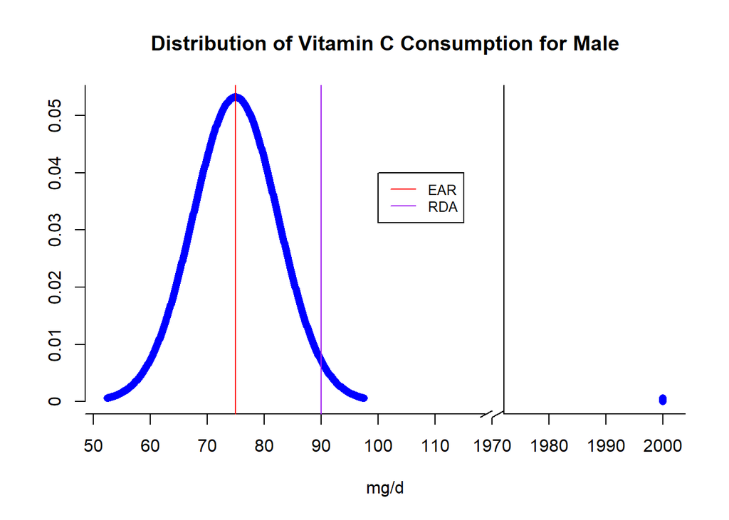

```r
ul = 2000
xmin = mean-sd*3
xmax = mean+sd*3
# Create a sequence of numbers between xmin and 2000 incrementing by 0.1
x <- seq(xmin, ul, by = .1)
xgap <- ifelse(x>xmax,2000, x)
# Choose the mean as 60 and standard deviation as 7.5.
y <- dnorm(x, mean, sd)
par(bty="n") # deleting the box
gap.plot(xgap,y, gap=c(120,1970), gap.axis="x", pch=16,
         col="blue", ylim=range(y),
         xtics=c(seq(30, 120, by = 10),seq(1970, 2010, by = 10)),
         xticlab=c(seq(30, 120, by = 10),seq(1970, 2010, by = 10)), xlab = 'mg/d',
         ylab ='', main="Distribution of Vitamin C Consumption for Male")
abline(v=mean, col="red")    #add EAR line
abline(v=A, col="purple")    # add RDA line
abline(v=seq(120,1970,100), col="white")  # hiding vertical lines
axis.break(1,120,style="slash")               # plotting slashes for breakpoints
legend(100, .04, legend=c("EAR", "RDA"),
       col=c("red", "purple"), lty=1:1, cex=0.8)
```

# Problem 1.171

# A) Solution:

```r
# percent of RDA (p-value)
pz5 = 0.05


# find z-value from p-value
z5= round(qnorm(pz5),2)
print(paste("z score for 5th percentile is", z5))
```

```
## [1] "z score for 5th percentile is -1.64"
```

```r
# percent of RDA (p-value)
pz50 = 0.50
# RDA
A50 = 79
# find z-value from p-value
z50= round(qnorm(pz50, lower.tail = TRUE),2)
print(paste("z score for 50th percentile is", z50))
```

```
## [1] "z score for 50th percentile is 0"
```

```r
# percent of RDA (p-value)
pz95 = 0.95

# find z-value from p-value
z95= round(qnorm(pz95, lower.tail = TRUE),2)
print(paste("z score for 95th percentile is", z95))
```

```
## [1] "z score for 95th percentile is 1.64"
```

We know z = (x-mean)/sd

So, mean = x-(sd*z)

But, for 50th percentile, z is 0 as p(z<=0.00) = .50

So, mean = A50-(sd*0)

Finally, mean = A50

```r
mean = A50
print(paste("The value of mean is",mean))
```

```
## [1] "The value of mean is 79"
```

```r
A95 = 142
sd = (A95-mean)/z95
print(paste("The value of standard deviation is",sd))
```

```
## [1] "The value of standard deviation is 38.4146341463415"
```

# B) Solution:

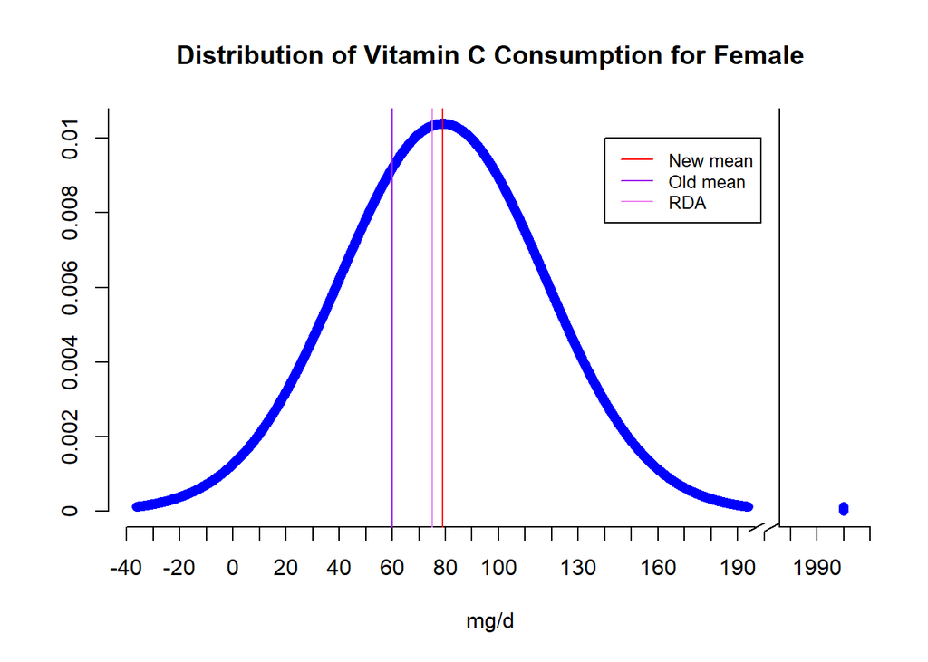

```r
ul = 2000
xmin = mean-sd*3
xmax = mean+sd*3
# Create a sequence of numbers between xmin and 2000 incrementing by 0.1
x <- seq(xmin, ul, by = .1)
xgap <- ifelse(x>xmax,2000, x)
# Choose the mean as 60 and standard deviation as 7.5.
y <- dnorm(x, mean, sd)
par(bty="n") # deleting the box
gap.plot(xgap,y, gap=c(200,1970), gap.axis="x", pch=16,
         col="blue", ylim=range(y),
         xtics=c(seq(-40, 200, by = 10),seq(1970, 2010, by = 10)),
         xticlab=c(seq(-40, 200, by = 10),seq(1970, 2010, by = 10)), xlab = 'mg/d',
         ylab ='', main="Distribution of Vitamin C Consumption for Female")
abline(v=mean, col="red")    #add new mean line
abline(v=60, col="purple")    # add old mean line
abline(v=75, col="violet")    # add RDA line
abline(v=seq(200,1970,100), col="white")  # hiding vertical lines
axis.break(1,200,style="slash")               # plotting slashes for breakpoints
legend(140, .01, legend=c("New mean", "Old mean", "RDA"),
       col=c("red", "purple", "violet"), lty=1:1, cex=0.8)
```

# C) Solution:

*As per the new graph, we can see that the new mean (79) is more than the previously estimated mean (60) and the new mean (79) which is at 50th percentile is also more than the RDA (75). So we can confidently say that majority of the female population consumes more vitamin C than the RDA on a daily basis.*

# Problem 1.172

# A) Solution:

```r
# percent of RDA (p-value)
pz5 = 0.05


# find z-value from p-value
z5= round(qnorm(pz5),2)
print(paste("z score for 5th percentile is", z5))
```

```
## [1] "z score for 5th percentile is -1.64"
```

```r
# percent of RDA (p-value)
pz50 = 0.50
# RDA
A50 = 114
# find z-value from p-value
z50= round(qnorm(pz50, lower.tail = TRUE),2)
print(paste("z score for 50th percentile is", z50))
```

```
## [1] "z score for 50th percentile is 0"
```

```r
# percent of RDA (p-value)
pz95 = 0.95

# find z-value from p-value
z95= round(qnorm(pz95, lower.tail = TRUE),2)
print(paste("z score for 95th percentile is", z95))
```

```
## [1] "z score for 95th percentile is 1.64"
```

We know z = (x-mean)/sd

So, mean = x - (sd*z)

But, for 50th percentile, z is 0 as p(z<=0.00) = .50

So, mean = A50-(sd*0)

Finally, mean = A50

```r
mean = A50
print(paste("The value of mean is",mean))
```

```
## [1] "The value of mean is 114"
```

```r
A95 = 217
sd = (A95-mean)/z95
print(paste("The value of standard deviation is",sd))
```

```
## [1] "The value of standard deviation is 62.8048780487805"
```

# B) Solution:

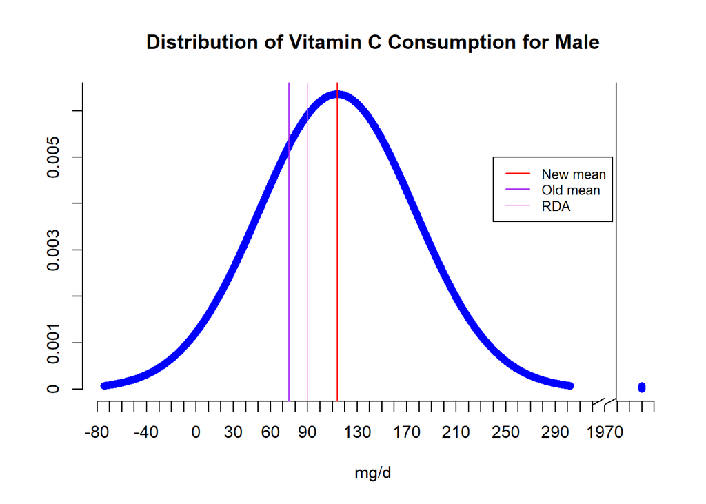

```r
ul = 2000
xmin = mean-sd*3
xmax = mean+sd*3
# Create a sequence of numbers between xmin and 2000 incrementing by 0.1
x <- seq(xmin, ul, by = .1)
xgap <- ifelse(x>xmax,2000, x)
# Choose the mean as 60 and standard deviation as 7.5.
y <- dnorm(x, mean, sd)
par(bty="n") # deleting the box
gap.plot(xgap,y, gap=c(330,1970), gap.axis="x", pch=16,
         col="blue", ylim=range(y),
         xtics=c(seq(-80, 330, by = 10),seq(1970, 2010, by = 10)),
         xticlab=c(seq(-80, 330, by = 10),seq(1970, 2010, by = 10)), xlab = 'mg/d',
         ylab ='', main="Distribution of Vitamin C Consumption for Male")
abline(v=mean, col="red")    #add new mean line
abline(v=75, col="purple")    # add old mean line
abline(v=90, col="violet")    # add RDA line
abline(v=seq(330,1970,100), col="white")  # hiding vertical lines
axis.break(1,330,style="slash")               # plotting slashes for breakpoints
legend(240, .005, legend=c("New mean", "Old mean", "RDA"),
       col=c("red", "purple", "violet"), lty=1:1, cex=0.8)
```

# C) Solution:

*As per the new graph, we can see that the new mean (114) is more than the previously estimated mean (75) and the new mean (114) which is at 50th percentile is also more than the RDA (90). So we can confidently say that majority of the male population consumes more vitamin C than the RDA on a daily basis.*

# Problem 1.176

# A) Solution:

For third graders’ current scores:

μ=70

σ=10

z = (x-μ)/σ

=>z = (x-70)/10 …..(1)

For desired score

μ=100

σ=20

so X-new =z*σ +μ

```
     =[(x-70)/10]*20 +100 ......(from 1)

     =2x-140+100

     =2x-40
```

So, a=-40 and b=2

# B) Solution:

For six graders’ current scores:

μ=80

σ=11

z = (x-μ)/σ

=>z = (x-80)/11 …..(1)

For desired score

μ=100

σ=20

so X-new =z*σ +μ

```
     =[(x-80)/11]*20 +100 ......(from 1)

     =(20x-1600+1100)/11

     =(20x-500)/11

     =1.82x-45.45
```

So, a=-45.45 and b=1.82

# C) Solution:

David’s transformed score =-40+2*72=104

Nancy’s transformed score = -45.45+1.82*78=96.51

David Scores higher as his standardized transformed score is higher.

# D) Solution:

For both third and six graders standardized scoring less than 75 as they have the same distribution:

```r
mean = 100
sd = 20
x = 75
z = (x-mean)/sd
z
```

```
## [1] -1.25
```

```r
pz = pnorm(z, lower.tail = TRUE)
print(paste("Percent value is", round(pz*100,2),"%"))
```

```
## [1] "Percent value is 10.56 %"
```

For non-standardized scoring:

```r
# for third graders
mean = 70
sd = 10
x = 75
z = (x-mean)/sd
z
```

```
## [1] 0.5
```

```r
pz = pnorm(z, lower.tail = TRUE)
print(paste("Percent value of third graders is", round(pz*100,2),"%"))
```

```
## [1] "Percent value of third graders is 69.15 %"
```

```r
# for sixth graders
mean = 80
sd = 11
x = 75
z = (x-mean)/sd
z
```

```
## [1] -0.4545455
```

```r
pz = pnorm(z, lower.tail = TRUE)
print(paste("Percent value of sixth graders is", round(pz*100,2),"%"))
```

```
## [1] "Percent value of sixth graders is 32.47 %"
```